# Análisis de contornos de otolitos con R

Curso corto de morfometría geométrica de contornos

Luis Cubillos

Noviembre 2026

# Presentación

La forma del contorno del otolito *sagitta* es una marca natural usada para identificar stocks de peces, porque integra factores genéticos y ambientales que cada individuo experimenta. Este curso corto enseña, paso a paso y con R, el flujo completo de un análisis de contornos: desde la **fotografía del otolito** hasta la exploración de la variación de forma con un **análisis de componentes principales**.

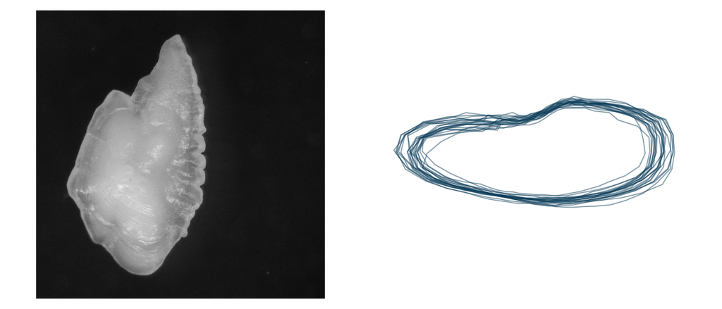

**Texto guía**: Claude, J. (2008). *Morphometrics with R*. Springer, Nueva York. Las funciones de R que se usan (`Conte`, `regularradius`, `efourier`, `iefourier`, `NEF`, `elipse`) son las del libro, con las correcciones de su fe de erratas (v1.8).

**Dirigido a**: estudiantes de posgrado, profesionales e investigadores en biología pesquera con conocimientos básicos de R.

# Programa

Cada módulo es una presentación HTML (formato *slidy*): use las flechas del teclado para avanzar, `C` para ver el índice de diapositivas y `A` para ver todas en una sola página. El código de cada diapositiva puede copiarse y ejecutarse en R.

### Módulo 1. Introducción a la morfometría geométrica de contornos de otolitos

El otolito como marca natural · forma y tamaño · morfometría tradicional vs. geométrica · landmarks, pseudolandmarks y configuraciones · métodos de Fourier para contornos · índices de forma · flujo de trabajo. *Claude (2008), cap. 1, secc. 2.1 y cap. 5.*

### Módulo 2. Preparación de imágenes: escala de grises, binarización y contorno

La imagen como matriz · lectura con `pixmap` · profundidad de gris, contraste e inversión · histograma · binarización manual y por el método de Otsu · extracción del contorno con `Conte()` · calibración de la escala. *Claude (2008), secc. 2.1.1, 2.2.5 y 2.2.6.*

### Módulo 3. Pseudolandmarks a lo largo del contorno

Abscisa curvilínea y radios equiangulares (`regularradius()`) · muestreo equidistante por perímetro · número de puntos · punto de inicio y sentido de recorrido · descriptores de tamaño e índices de forma · procesamiento por lotes. *Claude (2008), secc. 2.3.3 y 5.2.1.*

### Módulo 4. Preparación de datos de contornos: CSV y XLSX

Configuraciones como matriz, arreglo y data.frame · formatos apilado, largo y ancho · tabla de metadatos · leer y escribir CSV (`read.csv`, `write.csv2`) y XLSX (`readxl`, `writexl`) · validación · conversiones entre formatos. *Claude (2008), secc. 2.1.2 y 2.4.*

### Módulo 5. Descriptores de forma: Transformada Elíptica de Fourier

Fourier de radios, de ángulo tangente y elíptico · `efourier()` e `iefourier()` · reconstrucción con armónicos crecientes · normalización con `NEF()` y fe de erratas · matriz de coeficientes · poder acumulado. *Claude (2008), secc. 5.2.*

### Módulo 6. Análisis de componentes principales de contornos

Selección de armónicos por poder y varianza · ACP con `princomp()` · varianza explicada, puntajes y cargas · reconstrucción de formas extremas · morfoespacio · interpretación y precauciones. *Claude (2008), secc. 6.1.2.*

# Datos del curso

| Archivo | Contenido |
| --- | --- |
| `datos/otolito_scom.pgm` | Imagen de un otolito de sardina común (684 × 912 píxeles, grises) |
| `datos/mcolaz1.txt` … `mcolaz3.txt` | Contornos de merluza de cola (50 puntos x, y por otolito): Chiloé (26), Aysén (20), Magallanes (21) |
| `datos/oto0101.csv` | Un contorno de 50 puntos (ejemplo de CSV) |
| `datos/contornos_3zonas.csv` / `.xlsx` | Contornos en formato largo (generados en el módulo 4) |
| `datos/coef_nef_3zonas.csv` | Coeficientes de Fourier normalizados (módulo 5) |

| Código | Zona | Otolitos | LT promedio (cm) |
| --- | --- | --- | --- |
| Ch | Sistema Estuarino Chiloé | 26 | 60.6 |
| Ay | Sistema Estuarino Aysén | 20 | 53.1 |
| Ma | Sistema Estuarino Magallanes | 21 | 82.5 |

# Cómo usar el material

1. Descargue o clone el repositorio y abra la carpeta del curso en RStudio (el directorio de trabajo debe ser la carpeta que contiene `index.Rmd`).
2. Instale los paquetes:

```r
install.packages(c("pixmap", "readxl", "writexl", "rmarkdown", "knitr"))
install.packages("magick")   # opcional: convertir .jpg/.tif a .pgm/.ppm
```

3. Cargue las funciones del curso:

```r
for (f in list.files("R", full.names = TRUE)) source(f)
```

4. Abra cada `0X_*.Rmd` y ejecute los bloques de código en orden, o regenere todas las presentaciones con:

```r
source("_render.R")
```

Los módulos se encadenan: el 4 crea `datos/contornos_3zonas.csv`, que leen los módulos 5 y 6.

# Referencias

- Cadrin, S.X., Friedland, K.D. y Waldman, J.R. (eds.) (2005). *Stock Identification Methods: Applications in Fishery Science*. Elsevier Academic Press.
- Campana, S.E. (2004). *Photographic Atlas of Fish Otoliths of the Northwest Atlantic Ocean*. NRC Research Press.
- Campana, S.E. y Casselman, J.M. (1993). Stock discrimination using otolith shape analysis. *Canadian Journal of Fisheries and Aquatic Sciences* 50: 1062–1083.
- **Claude, J. (2008). *Morphometrics with R*. Springer, Nueva York.**
- Ferson, S., Rohlf, F.J. y Koehn, R.K. (1985). Measuring shape variation of two-dimensional outlines. *Systematic Zoology* 34: 59–68.
- Kuhl, F.P. y Giardina, C.R. (1982). Elliptic Fourier features of a closed contour. *Computer Graphics and Image Processing* 18: 236–258.

Material docente. Contacto: Luis Cubillos. Generado con R 4.6.1 y rmarkdown el 03-11-2026.